# Prophage clustering using syntenic Jaccard index

- Show All Code
- Hide All Code
- View Source

Author

Lakhansing Pardeshi

Published

July 20, 2025

This script cluster prophages using syntenic Jaccard index distance.

## Initial setup

```r
suppressPackageStartupMessages(library(tidyverse))
suppressPackageStartupMessages(library(here))
suppressPackageStartupMessages(library(magrittr))
suppressPackageStartupMessages(library(igraph))
suppressPackageStartupMessages(library(apcluster))
suppressPackageStartupMessages(library(dendextend))
suppressPackageStartupMessages(library(ComplexHeatmap))
suppressPackageStartupMessages(library(ape))
suppressPackageStartupMessages(library(logger))
suppressPackageStartupMessages(library(configr))

# cluster prophages to get representative phages

rm(list = ls())

source("https://raw.githubusercontent.com/lakhanp1/omics_utils/main/RScripts/utils.R")
source("scripts/utils/config_functions.R")
source("scripts/utils/homology_groups.R")
source("scripts/utils/heatmap_utils.R")
source("scripts/utils/compare_hg_sets.R")
################################################################################
set.seed(124)

confs <- prefix_config_paths(
    conf = suppressWarnings(configr::read.config(file = "project_config.yaml")),
    dir = "."
)

pangenome <- confs$data$pangenomes$pectobacterium.v2$name
panConf <- confs$data$pangenomes[[pangenome]]
prophageLenCutoff <- confs$analysis$prophages$cutoff_length

outDir <- confs$analysis$prophages$preprocessing$path

colorList <- list(
    jaccard = list(
        breaks = c(0, 0.1, 0.2, 0.3, 0.4, 0.5, 0.6, 0.7, 0.8, 0.9, 0.95, 0.97, 1),
        colors = viridisLite::viridis(n = 13, option = "magma")
    ),
    mash = list(
        breaks = c(0, 0.03, 0.05, 0.1, 0.15, 0.2, 0.3, 0.4, 0.5, 0.6, 0.7, 0.8, 1),
        colors = viridisLite::viridis(n = 13, option = "magma")
    )
)
```

## Import data

```r
sampleInfo <- get_metadata(file = panConf$files$metadata, genus = confs$genus)

sampleInfoList <- as.list_metadata(
    df = sampleInfo, sampleId, sampleName, SpeciesName, strain, nodeLabs, genomeId
)

prophagePool <- suppressMessages(
    readr::read_tsv(confs$analysis$prophages$preprocessing$files$prophage_pool)
) %>%
    dplyr::select(
        prophage_id, fragments, nFragments, parent, prophage_length, nHg, genomeId,
        completeness, checkv_quality, taxonomy
    )

fragmentedPhages <- dplyr::filter(prophagePool, nFragments > 1)
unfragPhages <- dplyr::filter(prophagePool, nFragments == 1) %>%
    dplyr::select(-parent)


simDf <- suppressMessages(
    readr::read_tsv(confs$analysis$prophages$preprocessing$files$pair_comparison)
)

mashMat <- suppressMessages(
    readr::read_tsv(confs$analysis$prophages$preprocessing$files$mash_dist)
) %>%
    tibble::column_to_rownames(var = "prophage_id") %>%
    as.matrix()

mashMat <- mashMat[unfragPhages$prophage_id, unfragPhages$prophage_id]

mashUpgma <- ape::read.tree(confs$analysis$prophages$preprocessing$files$mash_hclust)
```

Import HGs for raw prophages stored locally and map them to consolidated prophages

```r
# read prophage HGs stored locally
rawProHgs <- suppressMessages(
    readr::read_tsv(confs$analysis$prophages$preprocessing$files$raw_prophage_hg)
) %>%
    dplyr::select(prophage_id = id, hgs) %>%
    dplyr::mutate(
        hgs = stringr::str_split(hgs, ";")
    )

# merge the HGs from multiple prophage fragments when they are merged
prophageHgs <- dplyr::select(prophagePool, prophage_id, fragments) %>%
    dplyr::mutate(fragments = stringr::str_split(fragments, ";")) %>%
    tidyr::unnest(fragments) %>%
    dplyr::left_join(y = rawProHgs, by = c("fragments" = "prophage_id")) %>%
    dplyr::summarize(
        hgs = list(unique(unlist(hgs))),
        .by = prophage_id
    )
```

Total prophages to be clustered: 1369

## Process syntenic Jaccard similarity and MASH distance data

```r
# process data
phageCmpDf <- dplyr::bind_rows(
    simDf,
    dplyr::rename(simDf, p2 = phage1, p1 = phage2) %>%
        dplyr::rename(phage1 = p1, phage2 = p2)
)

allPhageJaccardMat <- tidyr::pivot_wider(
    phageCmpDf,
    id_cols = phage1,
    names_from = phage2,
    values_from = jaccardIndex
) %>%
    tibble::column_to_rownames(var = "phage1") %>%
    as.matrix()
```

**Important**

To remove the noise while clustering exclude:

- fragmented prophages
- all the prophages that show syntenic Jaccard index 0.5 or lower against other prophages

```r
jaccardMat <- allPhageJaccardMat[unfragPhages$prophage_id, unfragPhages$prophage_id]

if (all(is.na(diag(jaccardMat)))) {
    diag(jaccardMat) <- 1
}

if (!isSymmetric(jaccardMat)) {
    stop("pairwise Jaccard index matrix is not symmetric")
}

# convert to distance matrix
jacDistMat <- max(jaccardMat) - jaccardMat

quantile(jaccardMat, c(0, 0.25, 0.5, 0.75, seq(0.9, 0.99, by = 0.01), 0.995, 1))
```

```
    0%    25%    50%    75%    90%    91%    92%    93%    94%    95%    96%
0.0000 0.0000 0.0000 0.0000 0.2647 0.6296 0.6800 0.7200 0.7391 0.7500 0.7826
   97%    98%    99%  99.5%   100%
0.8000 0.8261 0.9000 0.9524 1.0000
```

```r
breakPoint <- 0.5
tempJcMat <- jaccardMat
diag(tempJcMat) <- NA
maxJc <- matrixStats::rowMaxs(tempJcMat, na.rm = TRUE, useNames = TRUE)

noisyNodes <- which(maxJc <= breakPoint)
trimmedNodes <- which(maxJc > breakPoint)
trimmedJaccardMat <- jaccardMat[unname(trimmedNodes), unname(trimmedNodes)]
```

## Hierarchical clustering of Jaccard similarity

A heatmap showing the syntenic Jaccard index between the singleton nodes identified above and the remaining nodes that will be used for clustering.

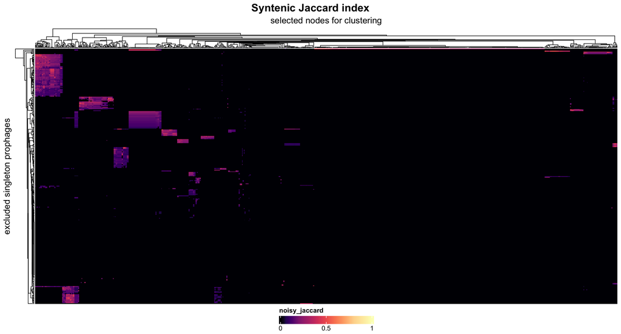

```r
ht_noise <- Heatmap(
    matrix = jaccardMat[unname(noisyNodes), unname(trimmedNodes)],
    name = "noisy_jaccard",
    column_title = "selected nodes for clustering",
    row_title = "excluded singleton prophages",
    col = circlize::colorRamp2(
        breaks = colorList$mash$breaks, colors = colorList$mash$colors
    ),
    heatmap_legend_param = list(
        direction = "horizontal", legend_width = unit(5, "cm")
    ),
    use_raster = TRUE, raster_quality = 3,
    show_row_names = FALSE, show_column_names = FALSE
)

ComplexHeatmap::draw(
    ht_noise,
    column_title = "Syntenic Jaccard index",
    column_title_gp = gpar(fontsize = 16, fontface = "bold"),
    heatmap_legend_side = "bottom"
)
```

**Important**

Noisy nodes identified above will be excluded from the hierarchical clustering of the prophages based on syntenic Jaccard index. Later, these noisy nodes will be added as singletons to the clusters identified by `hclust`.

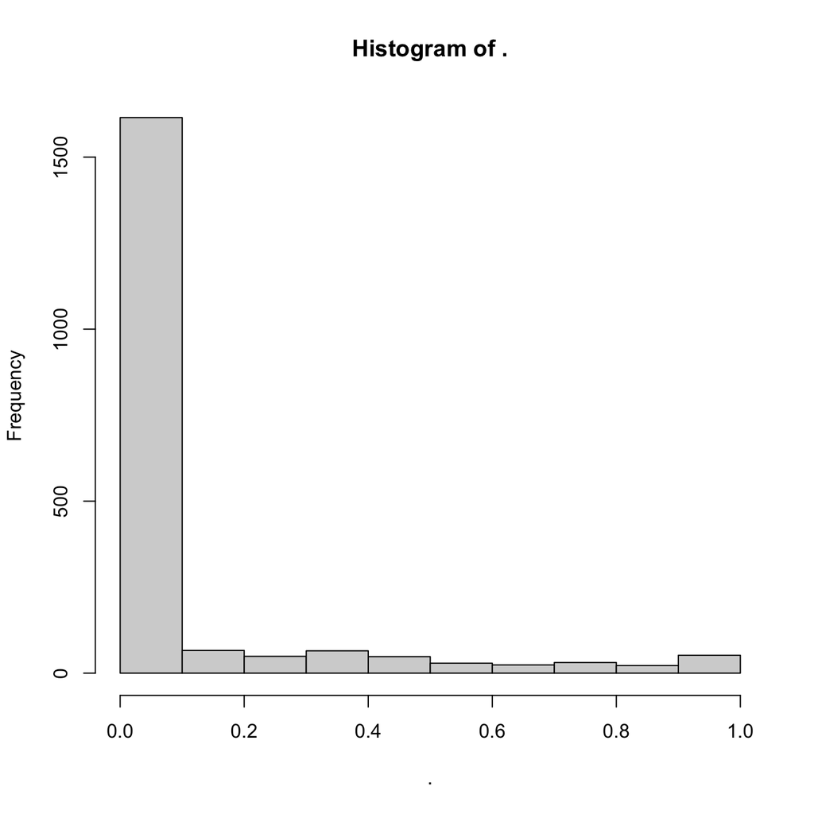

```r
phageHc <- hclust(
    as.dist(jacDistMat[unname(trimmedNodes), unname(trimmedNodes)]),
    method = "complete"
)
# plot(phageHc, hang = -1)

# hclust(as.dist(jacDistMat), method = "ward.D2") %>%
#   as.dendrogram() %>%
#   dendextend::ladderize() %>%
#   plot(horiz = TRUE)

phageDend <- as.dendrogram(phageHc) %>%
    dendextend::ladderize()

phageDend %>%
    dendextend::get_nodes_attr("height") %>%
    hist()
```

```r
# dendextend::cutree(as.dendrogram(blacl), h = 0.8) %>% table()

phagePhylo <- ape::as.phylo(phageDend)
```

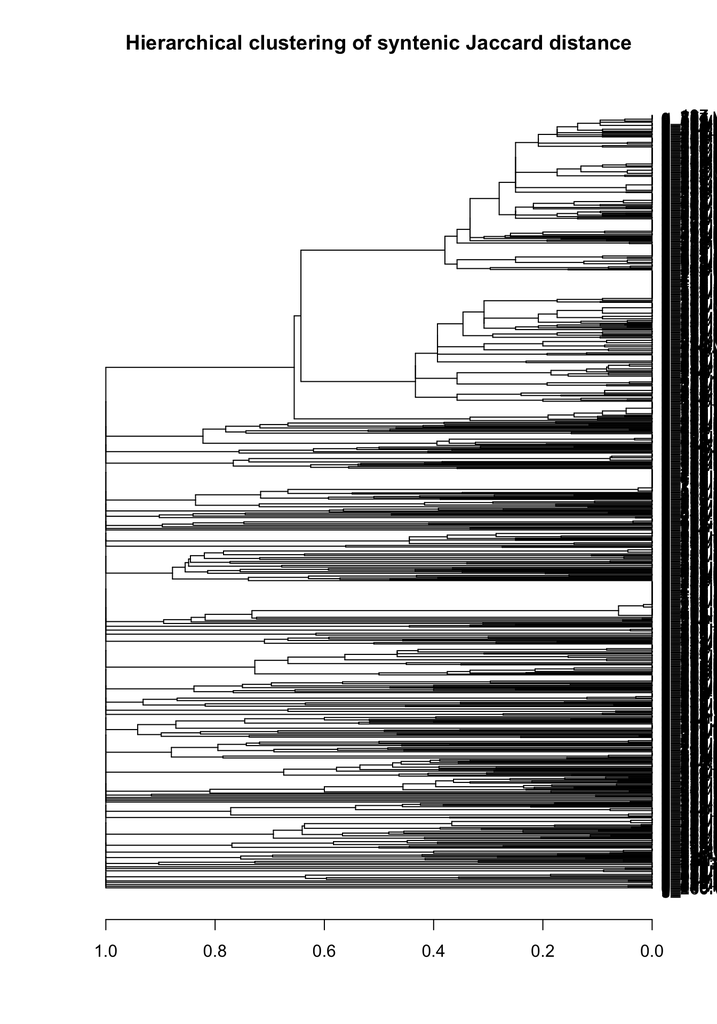

```r
rev(phageDend) %>%
    plot(
        horiz = TRUE,
        main = "Hierarchical clustering of syntenic Jaccard distance"
    )
```

## Visualize the clusters with data

### Syntenic Jaccard distance

**Important**

The heatmap below excludes obvious singletons i.e. noisy nodes identified above (n = 318). Thus this heatmap shows comparison of 1001 prophages.

```r
ht_jaccard <- plot_species_ANI_heatmap(
    mat = jaccardMat[phagePhylo$tip.label, phagePhylo$tip.label],
    phy = phagePhylo,
    name = "jaccard",
    column_title = "Syntenic Jaccard index",
    col = circlize::colorRamp2(
        breaks = colorList$jaccard$breaks, colors = colorList$jaccard$colors
    ),
    show_column_dend = TRUE, column_dend_height = unit(3, "cm"),
    heatmap_legend_param = list(
        direction = "horizontal", legend_width = unit(5, "cm")
    ),
    use_raster = TRUE, raster_quality = 2
)
```

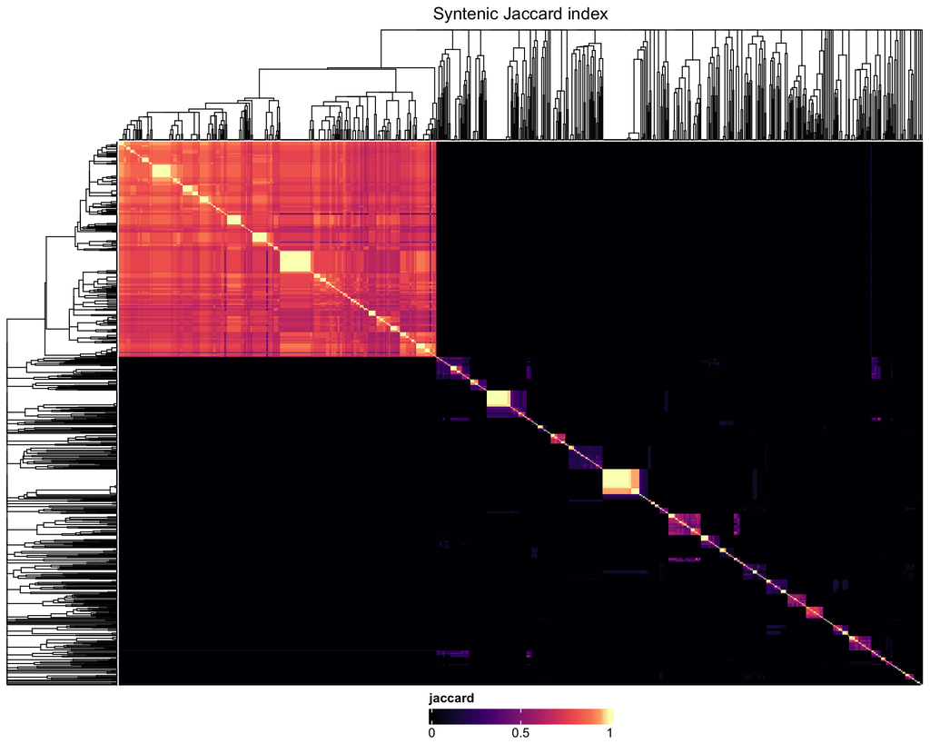

### Add MASH distance heatmap

```r
ht_mash <- plot_species_ANI_heatmap(
    mat = mashMat[phagePhylo$tip.label, phagePhylo$tip.label],
    phy = phagePhylo,
    name = "mash",
    column_title = "MASH distance",
    show_column_dend = FALSE,
    col = circlize::colorRamp2(
        breaks = colorList$mash$breaks, colors = colorList$mash$colors
    ),
    heatmap_legend_param = list(
        direction = "horizontal", legend_width = unit(5, "cm")
    ),
    use_raster = TRUE, raster_quality = 3
)

htList <- ht_jaccard + ht_mash
```

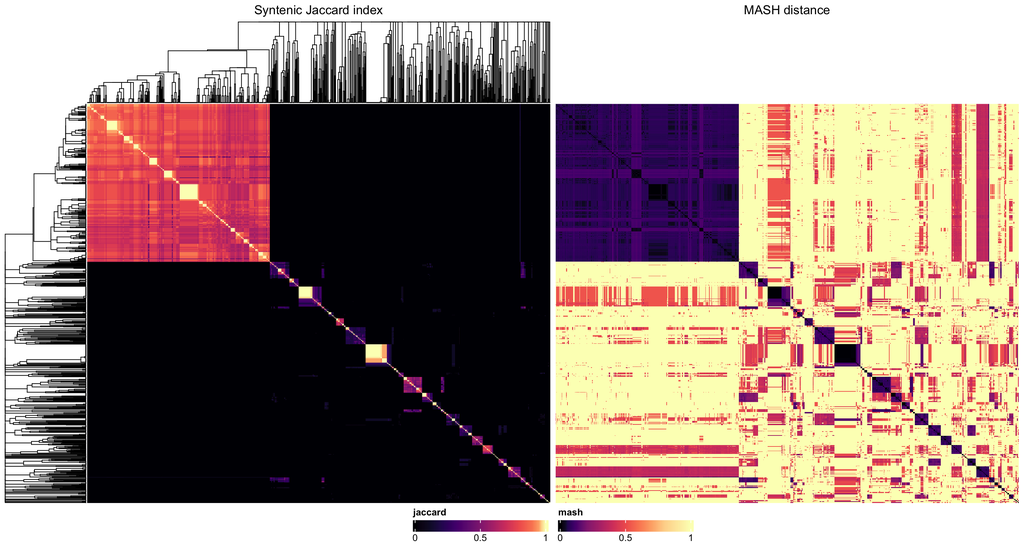

## Cut tree to generate clusters

**Important**

Here, the noisy nodes will be added as singletons to the prophage clusters.

```r
treeCut <- dendextend::cutree(tree = phageDend, h = 0.66)

phageGroups <- tibble::enframe(
    treeCut,
    name = "prophage_id", value = "phage_grp"
) %>%
    dplyr::bind_rows(
        tibble::tibble(
            prophage_id = names(noisyNodes),
            phage_grp = (1:length(noisyNodes)) + length(unique(treeCut))
        )
    ) %>%
    dplyr::mutate(
        phage_grp = paste("phage_grp_", phage_grp, sep = "")
    ) %>%
    dplyr::left_join(unfragPhages, by = "prophage_id")
```

Finally, add the 50 fragmented prophages which could be mapped to a prophage in the pool to the respective clusters of their best matching parent prophage.

```r
fragmentsToAdd <- dplyr::left_join(
    x = fragmentedPhages,
    y = dplyr::select(phageGroups, prophage_id, phage_grp),
    by = c("parent" = "prophage_id")
) %>%
    dplyr::select(-parent)

phageGroups <- dplyr::bind_rows(phageGroups, fragmentsToAdd) %>%
    tidyr::replace_na(list(nFragments = 1)) %>%
    dplyr::mutate(
        fragments = dplyr::if_else(is.na(fragments), prophage_id, fragments)
    ) %>%
    dplyr::select(prophage_id, phage_grp, fragments, nFragments, everything())
```

Cluster representatives are determined using the following criteria:

```r
# get cluster roots
clusterRoots <- split(x = phageGroups$prophage_id, f = phageGroups$phage_grp) %>%
    # .[c("phage_grp_114", "phage_grp_12", "phage_grp_131", "phage_grp_132", "phage_grp_173", "phage_grp_174")] %>%
    purrr::map_dfr(
        .f = function(x) {
            # root -> highest mean Jaccard index across group
            if (length(x) == 1) {
                rm <- setNames(object = 1, nm = x)
            } else {
                subJc <- allPhageJaccardMat[x, x]
                diag(subJc) <- NA

                rm <- matrixStats::rowMeans2(subJc, na.rm = TRUE, useNames = TRUE) %>%
                    sort(decreasing = TRUE) %>%
                    round(digits = 3)
            }

            return(
                tibble::tibble(
                    prophage_id = names(rm),
                    mean_grp_sim = rm,
                    grp_size = length(x),
                )
            )
        }
    )
```

Combine the clusters with cluster roots.

```r
rootedClusters <- dplyr::left_join(
    phageGroups, clusterRoots,
    by = "prophage_id"
) %>%
    dplyr::group_by(phage_grp) %>%
    dplyr::arrange(
        dplyr::desc(completeness),
        dplyr::desc(prophage_length),
        dplyr::desc(mean_grp_sim),
        .by_group = TRUE
    ) %>%
    dplyr::mutate(is_root = 1:n()) %>%
    dplyr::ungroup() %>%
    dplyr::mutate(
        is_root = dplyr::if_else(is_root == 1, 1, 0)
    ) %>%
    dplyr::left_join(y = prophageHgs, by = "prophage_id")


representatives <- dplyr::filter(rootedClusters, is_root == 1)

rootedClusters %<>% dplyr::left_join(
    y = dplyr::select(representatives, phage_grp, root_id = prophage_id),
    by = "phage_grp"
)
```

## Clustering statistics

Total prophages used for clustering: 1369

Total unique homology groups from prophages before clustering: 4801

Total prophage clusters: 436

Total unique homology groups of prophage representatives after clustering: 4493

```r
phageClusters <- dplyr::select(rootedClusters, -hgs) %>%
    dplyr::arrange(
        dplyr::desc(grp_size), phage_grp, desc(completeness), desc(mean_grp_sim)
    ) %>%
    dplyr::left_join(
        y = dplyr::select(
            sampleInfo, genomeId, sampleId, SpeciesName, nodepath.kmer_upgma,
            geo_loc_country, host, isolation_source, env_broad_scale, collection_year
        ),
        by = "genomeId"
    )

readr::write_tsv(
    phageClusters,
    file = confs$analysis$prophages$files$clusters
)
```

**Note**

What is the variation in genome ANI of the phages in the same group?

If the clustering is good, the representatives prophages should not have high syntenic Jaccard index against other representative prophages.

```r
repJacMat <- jaccardMat[representatives$prophage_id, representatives$prophage_id]

diag(repJacMat) <- NA

matrixStats::rowMaxs(repJacMat, useNames = TRUE, na.rm = TRUE) %>%
    sort(decreasing = TRUE) %>%
    head()
```

```
g_142.vir_2 g_327.vir_6 g_233.vir_4 g_150.vir_2   g_3.vir_3   g_4.vir_3
     0.5333      0.5333      0.5167      0.5167      0.5091      0.5091
```

## Draw figures again with representatives

### Representative prophages syntenic Jaccard index heatmap

```r
repDend <- hclust(
    as.dist(
        jacDistMat[representatives$prophage_id, representatives$prophage_id]
    ),
    method = "complete"
) %>%
    as.dendrogram() %>%
    dendextend::ladderize()

ht_jaccardRep <- plot_species_ANI_heatmap(
    mat = jaccardMat[representatives$prophage_id, representatives$prophage_id],
    phy = repDend,
    name = "jaccard",
    column_title = "Syntenic Jaccard index for representative prophages",
    col = circlize::colorRamp2(
        breaks = colorList$jaccard$breaks, colors = colorList$jaccard$colors
    ),
    use_raster = TRUE, raster_quality = 2,
    heatmap_legend_param = list(
        direction = "horizontal", legend_width = unit(5, "cm")
    )
)

ht_mashRep <- plot_species_ANI_heatmap(
    mat = mashMat[representatives$prophage_id, representatives$prophage_id],
    phy = repDend,
    name = "mash",
    column_title = "MASH distance",
    col = circlize::colorRamp2(
        breaks = colorList$mash$breaks, colors = colorList$mash$colors
    ),
    use_raster = TRUE, raster_quality = 2,
    heatmap_legend_param = list(
        direction = "horizontal", legend_width = unit(5, "cm")
    )
)

htListRep <- ht_jaccardRep + ht_mashRep
```

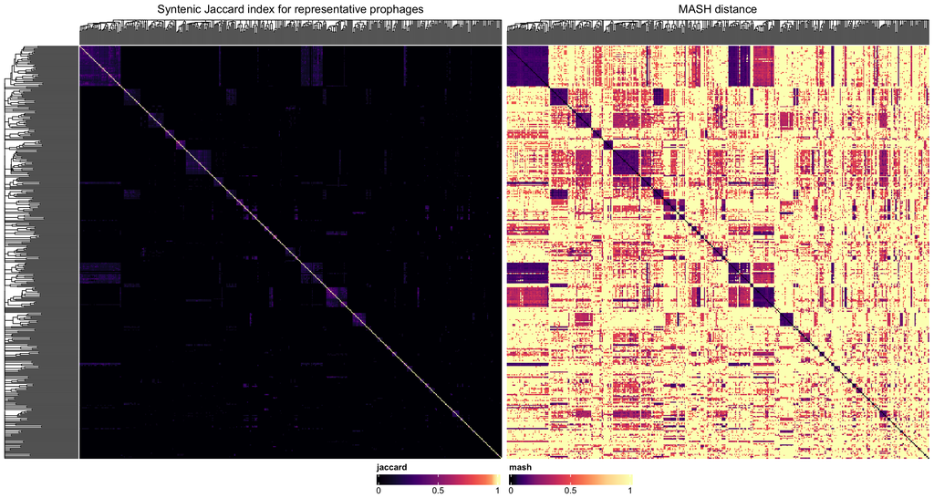

### Visualize the final dendrogram

All the 436 representatives which includes noisy nodes (n = 318) and cluster representatives (n = 118) obtained by clustering 1001 prophages, are visualized in this dendrogram. The later 118 nodes are colored in red.

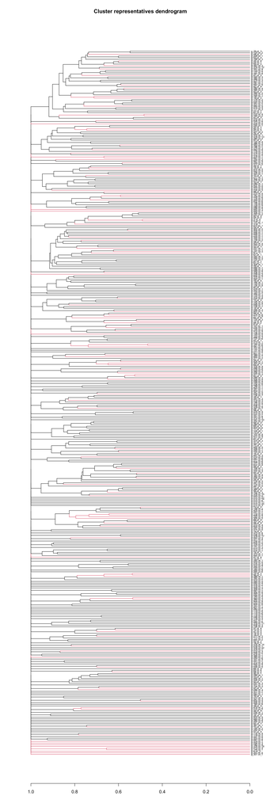

```r
rev(repDend) %>%
    dendextend::set(
        what = "by_labels_branches_col",
        value = setdiff(representatives$prophage_id, names(noisyNodes))
    ) %>%
    dendextend::set("labels_cex", 0.5) %>%
    plot(
        horiz = TRUE,
        main = "Cluster representatives dendrogram"
    )
```

Back to top